# Simulation Studies: Poisson Rate Model (GBSG)

Subgroup Identification with Incidence Rate Ratios

Author

Larry F. León

Published

April 26, 2026

# 1 Introduction

## 1.1 Motivation

This document validates the ForestSearch GLM extension for **count outcomes** (Poisson regression with offset) using the German Breast Cancer Study Group (GBSG) dataset. By treating each patient’s binary recurrence indicator (`status`) as a count (0 or 1) with `log(time_months)` as the exposure offset, we obtain incidence rate ratios (IRR) that approximate the Cox hazard ratios (HR) under exponential survival.

This design serves two purposes:

1. **Cross-validation with the Cox pipeline**: If the Poisson rate model identifies the same subgroup with similar effect sizes, this strengthens confidence in both approaches.
2. **GLM count simulation infrastructure**: Exercises `generate_glm_dgm()` with `outcome_type = "count"` and `offset_var`, validating the entire pipeline (DGM → calibration → simulation → ForestSearch → operating characteristics).

# 2 Data Preparation

```r
library(forestsearch)
library(survival)
library(data.table)
library(gt)
library(ggplot2)
library(doFuture)
library(foreach)

# Safe foreach result collection and worker resets are provided by
# forestsearch v0.2.0 via the exported helpers collect_results() and
# reset_workers() (R/forestsearch_helpers.R).  Call as
# forestsearch::collect_results(...) or just collect_results(...) after
# library(forestsearch).

timings <- list()
```

```r
t0 <- proc.time()[3]

df.analysis <- gbsg

df.analysis <- within(df.analysis, {
  id          <- seq_len(nrow(df.analysis))
  time_months <- rfstime / 30.4375
  grade3      <- ifelse(grade == "3", 1, 0)
  treat       <- hormon
})

# Dichotomise covariates for ForestSearch
df.analysis$z_age    <- as.factor(ifelse(df.analysis$age > median(df.analysis$age), 1L, 0L))
df.analysis$z_meno   <- as.factor(df.analysis$meno)
df.analysis$z_size   <- as.factor(ifelse(df.analysis$size > median(df.analysis$size), 1L, 0L))
df.analysis$z_grade3 <- as.factor(df.analysis$grade3)
df.analysis$z_nodes  <- as.factor(ifelse(df.analysis$nodes > median(df.analysis$nodes), 1L, 0L))
df.analysis$z_pgr    <- as.factor(ifelse(df.analysis$pgr > median(df.analysis$pgr), 1L, 0L))
df.analysis$z_er     <- as.factor(ifelse(df.analysis$er <= 0, 1L, 0L))

# ── Realistic analyst-facing candidate set ──────────────────────────────
# The truly-binary indicators are coerced to factors so forestsearch's
# is.continuous() detection treats them as categorical (no median /
# GRF cut attempted).  The continuous columns (age, size, nodes, pgr,
# er) are left in their RAW numeric form -- the search methods discover
# cuts.  The z_* factors built above remain on the data frame only for
# the DGM (factor_vars argument) and the truth flag.
for (v in analysis_binary_vars) {
  df.analysis[[v]] <- as.factor(df.analysis[[v]])
}
confounders_analysis <- c(analysis_continuous_vars, analysis_binary_vars)

cat(sprintf("GBSG: N = %d, events = %d (%.1f%%)\n",
    nrow(df.analysis), sum(df.analysis$status),
    100 * mean(df.analysis$status)))
```

```
#> GBSG: N = 686, events = 299 (43.6%)
```

```r
cat(sprintf("Median follow-up: %.1f months\n",
    median(df.analysis$time_months)))
```

```
#> Median follow-up: 35.6 months
```

```r
# Verify Poisson IRR ≈ Cox HR at ITT level
cox_itt <- coxph(Surv(time_months, status) ~ hormon, data = df.analysis)
pois_itt <- glm(status ~ hormon, family = poisson(),
                offset = log(pmax(time_months, 1e-6)),
                data = df.analysis)
cat(sprintf("\nITT Cox HR:      %.4f\n", exp(coef(cox_itt))))
```

```
#>
#> ITT Cox HR:      0.6949
```

```r
cat(sprintf("ITT Poisson IRR: %.4f\n", exp(coef(pois_itt)[["hormon"]])))
```

```
#> ITT Poisson IRR: 0.7007
```

```r
cat(sprintf("|HR - IRR|:      %.4f\n",
    abs(exp(coef(cox_itt)) - exp(coef(pois_itt)[["hormon"]]))))
```

```
#> |HR - IRR|:      0.0058
```

```r
# Subgroup prevalence
cat(sprintf("\nER-negative (z_er == 1): %d / %d (%.1f%%)\n",
    sum(df.analysis$z_er == 1), nrow(df.analysis),
    100 * mean(df.analysis$z_er == 1)))
```

```
#>
#> ER-negative (z_er == 1): 82 / 686 (12.0%)
```

```r
timings$data_prep <- proc.time()[3] - t0
```

# 3 Single-Data Analysis on Observed GBSG

**ImportantReal-data setting: no ground-truth classification**

This section analyses the **actual GBSG data** – not a simulated trial. The true harm subgroup in a real trial is **unknown**; it is the object the analysis is trying to estimate. We therefore report the subgroup ForestSearch identifies and the resulting arm-specific IRRs, but we **do not** compute classification metrics (sens / spec / PPV) against any reference subgroup – there is no clinical truth to classify against. Classification is only meaningful in the simulation setting of Section 6, where the DGM fixes a known $H$.

Before any simulation, run ForestSearch on the **actual GBSG data** with `details = TRUE` to examine every step of the procedure: LASSO screening, GRF variable importance, candidate enumeration, and bootstrap consistency.

**NoteWhat the analysis methods see**

The analysis candidate set (passed to `forestsearch()` / `grf.subg.harm.glm()` as `confounders.name`) is:

- **Continuous** (5): age, size, nodes, pgr, er
- **Binary** (2): meno, grade3

The methods discover cuts on the continuous covariates themselves; the TRUE cut (er $\le$ 0, i.e. ER-negative) is **not** provided.

**ForestSearch on observed GBSG (click to expand)**

```r
t0 <- proc.time()[3]

fs_gbsg <- tryCatch(
  suppressWarnings(forestsearch(
    df.analysis            = df.analysis,
    confounders.name       = confounders_analysis,
    outcome.name           = "status",
    treat.name             = "hormon",
    id.name                = "id",
    outcome_type           = "count",
    effect_measure         = "IRR",
    offset.name            = "time_months",
    effect.threshold       = fs_irr_threshold,
    consistency.threshold  = fs_irr_consistency,
    pconsistency.threshold = fs_pconsistency,
    fs.splits              = fs_splits,
    n.min                  = fs_n_min,
    d0.min                 = fs_d0_min,
    d1.min                 = fs_d1_min,
    maxk                   = fs_maxk,
    vi.grf.min             = fs_vi_grf_min,
    use_lasso              = fs_use_lasso,
    use_grf                = fs_use_grf,
    use_twostage           = TRUE,
    is.RCT                 = fs_is_rct,
    details                = TRUE,
    quiet                  = FALSE,
    seedit                 = fs_seedit,
    parallel_args          = list(
      plan = "sequential", workers = 1, show_message = FALSE
    )
  )),
  error = function(e) {
    warning("ForestSearch on observed data failed: ", e$message)
    NULL
  }
)
```

```
#>
#> [forestsearch] Subgroup Identification Configuration
#>   Outcome type:   count
#>   Effect measure: IRR (Incidence Rate Ratio)
#>   Scale:          log (ratio)
#>
#>   Screening:      IRR >= 1.25 (log: 0.2231)
#>   Consistency:    IRR >= 1.00 (log: 0.0000)
#>   Consistency rate threshold: 90%
#>
#>   Interpretation:
#>     Candidates: subgroup IRR >= 1.25
#>     Splits:     each split IRR >= 1.00
```

```
#>   Search Alignment Diagnostic
```

```
#>
#>   Outcome:    status (count)
```

```
#>   Offset:     time_months
```

```
#>   Treatment:  hormon
```

```
#>   Measure:    Incidence Rate Ratio (IRR)
```

```
#>
#>   ForestSearch searches for:
#>     Subgroups where hormon increases the event rate with offset = log(time_months)
#>     (IRR >= threshold)
```

```
#>
#>   Thresholds:
#>     Screening: IRR >= 1.250 in the candidate subgroup
#>     Consistency: IRR >= 1.000 in each bootstrap split
```

```
#>
#>   Variable screening:
```

```
#>     LASSO: LASSO screening: DISABLED
```

```
#>     GRF:   GRF sees log(status + 0.5) (variance-stabilising transform).
#>     Variable importance identifies covariates with
#>     heterogeneous treatment effects on the count scale.
```

```
#>
#>   No alignment concerns detected.
```

```
#> GRF subgroup: age <= 50 & age <= 43 & size <= 39
#> GRF cuts identified: 3
#>   Cuts: age <= 50, age <= 43, size <= 39
#> Candidate factors: 25
#>  [1] "age <= 50"    "age <= 43"    "size <= 39"   "age <= 53.1"  "age <= 53"
#>  [6] "age <= 46"    "age <= 61"    "size <= 29.3" "size <= 25"   "size <= 20"
#> [11] "size <= 35"   "nodes <= 5"   "nodes <= 3"   "nodes <= 1"   "nodes <= 7"
#> [16] "pgr <= 110"   "pgr <= 32.5"  "pgr <= 7"     "pgr <= 131.8" "er <= 96.3"
#> [21] "er <= 36"     "er <= 8"      "er <= 114"    "meno"         "grade3"
#> Number of possible configurations (<= maxk): maxk = 2 , # combinations = 1275
#> Per-arm subjects criteria: control >= 10, treatment >= 0
#> Sample size criteria: n >= 60
#> Subgroup search completed in 0.06 minutes
#>
#> --- Filtering Summary ---
#>   Combinations evaluated: 1275
#>   Passed variance check: 1205
#>   Passed prevalence (>= 0.025 ): 1205
#>   Passed redundancy check: 1155
#>   Passed subjects counts (d0>= 10, d1>= 0): 1155
#>   Passed sample size (n>= 60 ): 1017
#>   GLM model fit successfully: 1017
#>   Passed effect threshold (IRR >= 1.250): 16
#> -------------------------
#>
#> Found 16 subgroup candidate(s)
#> # of candidate subgroups (meeting all criteria) = 16
#> # of unique initial candidates: 16
#> # Restricting to top stop_Kgroups = 10
#> # of candidates to evaluate: 10
#> # Early stop threshold: 0.95
#> Parallel config: workers = 1 , batch_size = 1
#> Batch 1 / 10 : candidates 1 - 1
#> Batch 2 / 10 : candidates 2 - 2
#> Batch 3 / 10 : candidates 3 - 3
#> Batch 4 / 10 : candidates 4 - 4
#> Batch 5 / 10 : candidates 5 - 5
#> Batch 6 / 10 : candidates 6 - 6
#> Batch 7 / 10 : candidates 7 - 7
#> Batch 8 / 10 : candidates 8 - 8
#> Batch 9 / 10 : candidates 9 - 9
#> Batch 10 / 10 : candidates 10 - 10
#> Evaluated 10 of 10 candidates (complete)
#> 1 subgroups passed consistency threshold
#> SG focus = hr
#> Seconds and minutes forestsearch overall = 12.887 0.2148
#> Consistency algorithm used: twostage
#> Subgroup identified: !{size <= 29.3} & {er <= 8}
```

**ForestSearch on observed GBSG (click to expand)**

```r
timings$single_data_fs <- proc.time()[3] - t0
cat(sprintf("\nForestSearch (real data) completed in %.1f sec\n",
            timings$single_data_fs))
```

```
#>
#> ForestSearch (real data) completed in 12.9 sec
```

## 3.1 Examine Result

**Examine FS result on observed GBSG (click to expand)**

```r
cat("\n=== ForestSearch Result (Observed GBSG) ===\n")
```

```
#>
#> === ForestSearch Result (Observed GBSG) ===
```

**Examine FS result on observed GBSG (click to expand)**

```r
if (!is.null(fs_gbsg) && !is.null(fs_gbsg$grp.consistency)) {
  sg <- fs_gbsg$grp.consistency$sg.harm
  if (!is.null(sg) && length(sg) > 0 && !all(is.na(sg))) {
    cat("Subgroup identified:", paste(sg, collapse = " & "), "\n")

    df_est <- fs_gbsg$df.est
    in_H  <- df_est$treat.recommend == 0
    in_Hc <- df_est$treat.recommend == 1
    cat(sprintf("  Size(H): %d,  Size(Hc): %d\n",
        sum(in_H), sum(in_Hc)))

    .pois_fit <- function(d) {
      tryCatch(
        glm(status ~ hormon, data = d, family = poisson(),
            offset = log(pmax(d$time_months, 1e-6))),
        error = function(e) NULL)
    }

    if (sum(in_H) >= 10) {
      fit_H <- .pois_fit(df_est[in_H, ])
      if (!is.null(fit_H)) {
        cat(sprintf("  IRR(H):  %.3f\n",
            exp(coef(fit_H)[["hormon"]])))
      }
    }
    if (sum(in_Hc) >= 10) {
      fit_Hc <- .pois_fit(df_est[in_Hc, ])
      if (!is.null(fit_Hc)) {
        cat(sprintf("  IRR(Hc): %.3f\n",
            exp(coef(fit_Hc)[["hormon"]])))
      }
    }

    fit_itt <- .pois_fit(df_est)
    if (!is.null(fit_itt)) {
      cat(sprintf("  IRR(ITT): %.3f\n",
          exp(coef(fit_itt)[["hormon"]])))
    }
  } else {
    cat("No subgroup identified by ForestSearch.\n")
  }
} else {
  cat("ForestSearch did not return grp.consistency.\n")
}
```

```
#> Subgroup identified: !{size <= 29.3} & {er <= 8}
#>   Size(H): 76,  Size(Hc): 610
#>   IRR(H):  1.692
#>   IRR(Hc): 0.648
#>   IRR(ITT): 0.701
```

## 3.2 GRF Standalone on Observed Data

This vignette runs GRF on the observed data even though `run_grf = FALSE` for the simulation loop – a one-time call on real data is cheap and provides a useful comparison point.

**GRF standalone on observed GBSG (click to expand)**

```r
grf_gbsg <- tryCatch(
  grf.subg.harm.glm(
    data             = df.analysis,
    confounders.name = confounders_analysis,
    outcome.name     = "status",
    treat.name       = "hormon",
    id.name          = "id",
    outcome_type     = "count",
    effect_measure   = "IRR",
    offset.name      = "time_months",
    RCT              = TRUE,
    sg.criterion     = "mDiff",
    seedit           = fs_seedit,
    details          = TRUE
  ),
  error = function(e) {
    warning("GRF on observed data failed: ", e$message)
    NULL
  }
)
```

**GRF standalone on observed GBSG (click to expand)**

```r
if (!is.null(grf_gbsg) &&
    !is.null(grf_gbsg$sg.harm.id) &&
    length(grf_gbsg$sg.harm.id) > 0L) {
  cat("GRF subgroup:",
      paste(grf_gbsg$sg.harm.id, collapse = " & "), "\n")
  grf_H <- grf_gbsg$data$treat.recommend == 0
  cat(sprintf("  Size(H): %d,  Size(Hc): %d\n",
      sum(grf_H), sum(!grf_H)))
} else {
  cat("GRF: no subgroup identified.\n")
}
```

```
#> GRF: no subgroup identified.
```

## 3.3 FS vs GRF Concordance on Observed Data

When a method does not detect a subgroup, its classification is “all subjects to $H^c$” (`treat.recommend = 1` for everyone). `compare_fs_subgroups()` handles this automatically – no manual fallback is needed.

```r
if (!is.null(fs_gbsg) && !is.null(grf_gbsg)) {
  sg_compare <- compare_fs_subgroups(
    fs1                = fs_gbsg,
    fs2                = grf_gbsg,
    label1             = "ForestSearch",
    label2             = "GRF Standalone",
    id.name            = "id",
    subgroup_notation  = "harm",
    title              = "FS vs GRF: Subgroup Membership Concordance",
    subtitle           = "GBSG observed data (Poisson harm search, raw covariates)",
    font_size          = 13
  )
  sg_compare$table
}
```

[output not shown]

# 4 Creating the Poisson DGM

The GLM DGM fits a Poisson regression with offset to the observed GBSG data, creates a super-population with individual-level potential outcome means ($\mu_0$, $\mu_1$), and computes true subgroup effects on the IRR scale.

## 4.1 Step 1: Initial DGM

```r
t0 <- proc.time()[3]

dgm_alt_init <- generate_glm_dgm(
  data          = df.analysis,
  factor_vars   = dgm_factor_vars,
  outcome_var   = "status",
  treatment_var = "hormon",
  outcome_type  = "count",
  effect_measure = "IRR",
  offset_var    = "time_months",
  subgroup_vars = dgm_subgroup_vars,
  subgroup_cuts = dgm_subgroup_cuts,
  model         = "alt",
  k_inter       = 0,
  n_super       = dgm_n_super,
  seed          = sim_seed,
  verbose       = TRUE
)
```

```
#> === generate_glm_dgm() ===
#>   outcome_type:   count
#>   effect_measure: IRR
#>   model:          alt
#>   k_inter:        0.000
#>   k_treat:        1.000
#>   n_super:        5000
#>   n observations: 686
#>   factor vars:    7
#>
#> === Subgroup Definitions ===
#>    z_er == 1
#>     Proportion in subgroup: 0.12
#>
#> Overall subgroup (all conditions met):
#>   Size: 82 out of 686
#>   Proportion: 0.12
#>
#> Baseline GLM fit (no interaction):
#>   AIC: 1328.5
#>   Treatment coefficient: -0.4114 (IRR = 0.663)
#>   Offset variable: time_months
#>   Interaction shift (k_inter): 0.0000
#>
#> === DGM Summary ===
#>   Effect(Q):   0.6627  (IRR)
#>   Effect(Qc):  0.6627  (IRR)
#>   Effect(ITT): 0.6627  (IRR)
#>   Subgroup prevalence: 11.8%
```

```r
cat("\n=== Initial GBSG Poisson DGM ===\n")
```

```
#>
#> === Initial GBSG Poisson DGM ===
```

```r
cat("  IRR(H):  ", round(dgm_alt_init$hazard_ratios$harm_subgroup, 3), "\n")
```

```
#>   IRR(H):   0.663
```

```r
cat("  IRR(Hc): ", round(dgm_alt_init$hazard_ratios$no_harm_subgroup, 3), "\n")
```

```
#>   IRR(Hc):  0.663
```

```r
cat("  IRR(ITT):", round(dgm_alt_init$hazard_ratios$overall, 3), "\n")
```

```
#>   IRR(ITT): 0.663
```

```r
timings$dgm_init <- proc.time()[3] - t0
```

## 4.2 Step 2: Calibrate for Target IRR

The `k_inter` parameter shifts the log-rate for subgroup H members under treatment. We search over a grid to find the value producing the target IRR(H).

```r
t0 <- proc.time()[3]

dgm_calibrated <- calibrate_glm_interaction(
  data          = df.analysis,
  factor_vars   = dgm_factor_vars,
  outcome_var   = "status",
  treatment_var = "hormon",
  target_effect = cal_target_irr,
  outcome_type  = "count",
  effect_measure = "IRR",
  offset_var    = "time_months",
  subgroup_vars = dgm_subgroup_vars,
  subgroup_cuts = dgm_subgroup_cuts,
  k_inter_range = cal_k_grid_range,
  grid_step     = cal_grid_step,
  n_super       = dgm_n_super,
  seed          = sim_seed,
  verbose       = TRUE
)
```

```
#> Calibrating: target IRR = 2.000 (search target: 2.0000)
#>   Grid: 0.00 to 3.00 by 0.050 (61 values)
#>   Best: k_inter = 1.100 -> Effect(Q) = 1.9909 (search target: 2.0000)
#> === generate_glm_dgm() ===
#>   outcome_type:   count
#>   effect_measure: IRR
#>   model:          alt
#>   k_inter:        1.100
#>   k_treat:        1.000
#>   n_super:        5000
#>   n observations: 686
#>   factor vars:    7
#>
#> === Subgroup Definitions ===
#>    z_er == 1
#>     Proportion in subgroup: 0.12
#>
#> Overall subgroup (all conditions met):
#>   Size: 82 out of 686
#>   Proportion: 0.12
#>
#> Baseline GLM fit (no interaction):
#>   AIC: 1328.5
#>   Treatment coefficient: -0.4114 (IRR = 0.663)
#>   Offset variable: time_months
#>   Interaction shift (k_inter): 1.1000
#>
#> === DGM Summary ===
#>   Effect(Q):   1.9909  (IRR)
#>   Effect(Qc):  0.6627  (IRR)
#>   Effect(ITT): 0.8433  (IRR)
#>   Subgroup prevalence: 11.8%
#>
#> Calibration complete: k_inter = 1.100
#>   Effect(Q):   1.9909  (actual Y scale)
#>   Effect(Qc):  0.6627
#>   Effect(ITT): 0.8433
```

```r
cat("\n=== Calibrated GBSG Poisson DGM ===\n")
```

```
#>
#> === Calibrated GBSG Poisson DGM ===
```

```r
cat("  IRR(H):  ", round(dgm_calibrated$hazard_ratios$harm_subgroup, 3),
    " (target:", cal_target_irr, ")\n")
```

```
#>   IRR(H):   1.991  (target: 2 )
```

```r
cat("  IRR(Hc): ", round(dgm_calibrated$hazard_ratios$no_harm_subgroup, 3), "\n")
```

```
#>   IRR(Hc):  0.663
```

```r
cat("  IRR(ITT):", round(dgm_calibrated$hazard_ratios$overall, 3), "\n")
```

```
#>   IRR(ITT): 0.843
```

```r
cat("  k_inter: ", dgm_calibrated$model_params$k_inter, "\n")
```

```
#>   k_inter:  1.1
```

```r
timings$calibrate <- proc.time()[3] - t0
```

### 4.2.1 Calibration Curve

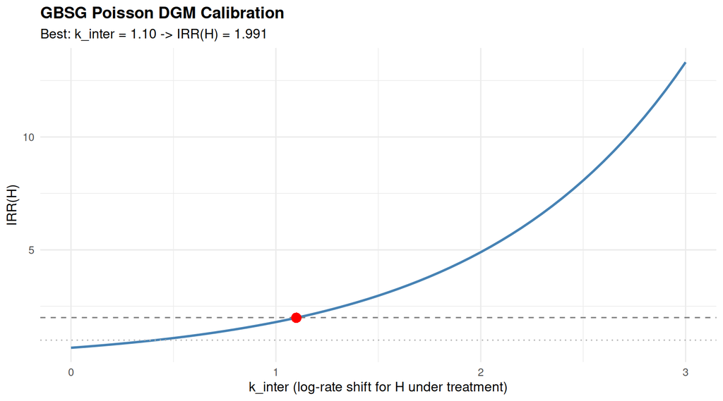

Calibration of k_inter: IRR(H) as a function of the interaction parameter.

```r
cal_grid <- seq(cal_k_grid_range[1], cal_k_grid_range[2], by = cal_grid_step)
cal_irr_H <- vapply(cal_grid, function(k) {
  d <- generate_glm_dgm(
    data = df.analysis, factor_vars = dgm_factor_vars,
    outcome_var = "status", treatment_var = "hormon",
    outcome_type = "count", effect_measure = "IRR",
    offset_var = "time_months",
    subgroup_vars = dgm_subgroup_vars,
    subgroup_cuts = dgm_subgroup_cuts, model = "alt",
    k_inter = k, n_super = dgm_n_super, seed = sim_seed
  )
  d$hazard_ratios$harm_subgroup
}, numeric(1))

cal_df <- data.frame(k_inter = cal_grid, irr_H = cal_irr_H)
best_k <- dgm_calibrated$model_params$k_inter

ggplot(cal_df, aes(x = k_inter, y = irr_H)) +
  geom_line(linewidth = 1, colour = "steelblue") +
  geom_hline(yintercept = cal_target_irr, linetype = "dashed",
             colour = "grey50") +
  geom_hline(yintercept = 1.0, linetype = "dotted",
             colour = "grey70") +
  geom_point(
    data = data.frame(k_inter = best_k,
                      irr_H = dgm_calibrated$hazard_ratios$harm_subgroup),
    colour = "red", size = 4, shape = 16
  ) +
  labs(
    x = "k_inter (log-rate shift for H under treatment)",
    y = "IRR(H)",
    title = "GBSG Poisson DGM Calibration",
    subtitle = sprintf("Best: k_inter = %.2f -> IRR(H) = %.3f",
      best_k, dgm_calibrated$hazard_ratios$harm_subgroup)
  ) +
  theme_minimal(base_size = 12) +
  theme(plot.title = element_text(face = "bold"))
```

## 4.3 Step 3: Null DGM

Under `model = "null"`, the interaction is zeroed out — no treatment effect heterogeneity.

```r
t0 <- proc.time()[3]

dgm_null <- generate_glm_dgm(
  data          = df.analysis,
  factor_vars   = dgm_factor_vars,
  outcome_var   = "status",
  treatment_var = "hormon",
  outcome_type  = "count",
  effect_measure = "IRR",
  offset_var    = "time_months",
  subgroup_vars = dgm_subgroup_vars,
  subgroup_cuts = dgm_subgroup_cuts,
  model         = "null",
  n_super       = dgm_n_super,
  seed          = sim_seed,
  verbose       = TRUE
)
```

```
#> === generate_glm_dgm() ===
#>   outcome_type:   count
#>   effect_measure: IRR
#>   model:          null
#>   k_inter:        0.000
#>   k_treat:        1.000
#>   n_super:        5000
#>   n observations: 686
#>   factor vars:    7
#>
#> === Subgroup Definitions ===
#>    z_er == 1
#>     Proportion in subgroup: 0.12
#>
#> Overall subgroup (all conditions met):
#>   Size: 82 out of 686
#>   Proportion: 0.12
#>
#> Baseline GLM fit (no interaction):
#>   AIC: 1328.5
#>   Treatment coefficient: -0.4114 (IRR = 0.663)
#>   Offset variable: time_months
#>   Interaction shift (k_inter): 0.0000 (null model: forced to 0)
#>
#> === DGM Summary ===
#>   Effect(Q):   NA  (IRR)
#>   Effect(Qc):  0.6627  (IRR)
#>   Effect(ITT): 0.6627  (IRR)
#>   Subgroup prevalence: 0.0%
```

```r
cat("\n=== GBSG Null DGM ===\n")
```

```
#>
#> === GBSG Null DGM ===
```

```r
cat("  IRR(ITT):", round(dgm_null$hazard_ratios$overall, 3), "\n")
```

```
#>   IRR(ITT): 0.663
```

```r
cat("  IRR(H):  ", round(dgm_null$hazard_ratios$harm_subgroup, 3), "\n")
```

```
#>   IRR(H):   NA
```

```r
cat("  IRR(Hc): ", round(dgm_null$hazard_ratios$no_harm_subgroup, 3), "\n")
```

```
#>   IRR(Hc):  0.663
```

```r
timings$dgm_null <- proc.time()[3] - t0
```

# 5 Single Trial Verification

**WarningSingle-replicate caveat: realistic-analysis variance**

This section verifies the simulator pipeline by drawing one trial from `dgm_calibrated`. Because the analysis methods see covariates in their RAW form (not the discretised z-factors), variable-screening steps such as LASSO and GRF must rediscover the truth-defining variables from scratch in each replicate. Under modest sample sizes (n = 686 per trial here), it is **expected** that any single replicate may fail to retain the true subgroup-defining variables – this is the price of the realistic-analysis pattern, not a bug.

Reliable inference about method behaviour comes from the **full simulation loop** in Section 7, where the operating characteristics aggregate across 1000 simulations (Section 7.1). The single-replicate output below is a pipeline- sanity check, not a performance claim.

```r
t0 <- proc.time()[3]

df_single <- simulate_from_glm_dgm(
  dgm  = dgm_calibrated,
  n    = sim_n_sample,
  seed = sim_seed + 1L
)

cat(sprintf("Single trial: N = %d, event rate = %.1f%%\n",
    nrow(df_single), 100 * mean(df_single$y_sim)))
```

```
#> Single trial: N = 686, event rate = 44.9%
```

```r
cat(sprintf("  H prevalence: %.1f%%\n",
    100 * mean(df_single$flag_harm)))
```

```
#>   H prevalence: 11.5%
```

```r
# Verify IRR in the simulated data
fit_single <- glm(y_sim ~ treat_sim, data = df_single, family = poisson(),
                  offset = log(pmax(df_single$time_months, 1e-6)))
cat(sprintf("  Simulated ITT IRR: %.3f (DGM: %.3f)\n",
    exp(coef(fit_single)["treat_sim"]),
    dgm_calibrated$hazard_ratios$overall))
```

```
#>   Simulated ITT IRR: 0.732 (DGM: 0.843)
```

```r
timings$single_trial <- proc.time()[3] - t0
```

# 6 Running Simulation Studies

## 6.1 Setup

```r
plan(multisession, workers = n_workers)
cat("Using", n_workers, "parallel workers\n")
```

```
#> Using 12 parallel workers
```

```r
# Analysis candidate set: raw continuous + factor binaries (NOT the
# discretised z_* variables).  Defined in the setup + prepare-data
# chunks so the variable is just referenced here.
confounders_gbsg <- confounders_analysis

fs_params <- list(
  outcome.name           = "y_sim",
  treat.name             = "treat_sim",
  id.name                = "id",

  # GLM pipeline
  outcome_type           = "count",
  effect_measure         = "IRR",
  offset.name            = "time_months",

  # Variable screening
  use_lasso              = fs_use_lasso,
  use_grf                = fs_use_grf,

  # Consistency algorithm (v0.2.0 default: 3-10x speedup)
  use_twostage           = TRUE,

  # Subgroup detection thresholds (GLM-era names)
  effect.threshold       = fs_irr_threshold,
  consistency.threshold  = fs_irr_consistency,
  pconsistency.threshold = fs_pconsistency,

  # Computational constraints
  fs.splits              = fs_splits,
  n.min                  = fs_n_min,
  d0.min                 = fs_d0_min,
  d1.min                 = fs_d1_min,
  maxk                   = fs_maxk,
  vi.grf.min             = fs_vi_grf_min,
  seedit                 = fs_seedit,

  # Inner parallelism: sequential within each worker
  parallel_args          = list(
    plan = "sequential", workers = 1, show_message = FALSE
  )
)
```

## 6.2 Alternative Hypothesis Simulations

```r
cat("Running", nsims_alt, "simulations under H1...\n")
```

```
#> Running 1000 simulations under H1...
```

```r
t0 <- proc.time()[3]

results_alt_raw <- foreach(
  sim = seq_len(nsims_alt),
  .errorhandling = "pass",
  .options.future = list(
    packages = c("forestsearch", "survival", "data.table", "future"),
    seed = TRUE
  )
) %dofuture% {
  future::plan("sequential")
  run_simulation_analysis(
    sim_id           = sim,
    dgm              = dgm_calibrated,
    n_sample         = sim_n_sample,
    confounders_base = confounders_gbsg,
    n_add_noise      = sim_n_noise,
    run_fs           = run_fs,
    run_fs_grf       = run_fs_grf,
    run_grf          = run_grf,
    fs_params        = fs_params,
    verbose          = FALSE
  )
}

timings$sims_alt <- proc.time()[3] - t0

results_alt <- collect_results(results_alt_raw, "H1 alt")
n_failed_alt <- attr(results_alt, "n_failed")

cat("Completed in", round(timings$sims_alt / 60, 1), "minutes\n")
```

```
#> Completed in 9.7 minutes
```

```r
cat("Results:", nrow(results_alt), "rows\n")
```

```
#> Results: 1000 rows
```

```r
if (n_failed_alt > 0) cat(sprintf("  *** %d FAILED ***\n", n_failed_alt))
cat(sprintf("Detection rate: %.1f%%\n",
    100 * mean(results_alt$any.H[results_alt$analysis == "FS"])))
```

```
#> Detection rate: 93.9%
```

## 6.3 Null Hypothesis Simulations

```r
# Reset worker pool between alt and null phases to prevent memory
# accumulation and worker bloat.  Without this, null sims run on
# bloated workers and can be substantially slower.
# reset_workers() is exported from forestsearch v0.2.0.
forestsearch::reset_workers(workers = n_workers)
```

```
#> reset_workers: plan reset to FutureStrategy with 12 worker(s) (was FutureStrategy).
```

```r
cat("Running", nsims_null, "simulations under H0...\n")
```

```
#> Running 2000 simulations under H0...
```

```r
t0 <- proc.time()[3]

results_null_raw <- foreach(
  sim = seq_len(nsims_null),
  .errorhandling = "pass",
  .options.future = list(
    packages = c("forestsearch", "survival", "data.table", "future"),
    seed = TRUE
  )
) %dofuture% {
  future::plan("sequential")
  run_simulation_analysis(
    sim_id           = sim,
    dgm              = dgm_null,
    n_sample         = sim_n_sample,
    confounders_base = confounders_gbsg,
    n_add_noise      = sim_n_noise,
    run_fs           = run_fs,
    run_fs_grf       = run_fs_grf,
    run_grf          = run_grf,
    fs_params        = fs_params,
    verbose          = FALSE
  )
}

timings$sims_null <- proc.time()[3] - t0

results_null <- collect_results(results_null_raw, "H0 null")
n_failed_null <- attr(results_null, "n_failed")

cat("Completed in", round(timings$sims_null / 60, 1), "minutes\n")
```

```
#> Completed in 22 minutes
```

```r
if (n_failed_null > 0) cat(sprintf("  *** %d FAILED ***\n", n_failed_null))
cat(sprintf("False discovery rate: %.1f%%\n",
    100 * mean(results_null$any.H[results_null$analysis == "FS"])))
```

```
#> False discovery rate: 45.8%
```

```r
plan(sequential)
```

```r
if (save_results) {
  if (!dir.exists(output_dir)) dir.create(output_dir, recursive = TRUE)

  bundle <- list(
    results_alt    = results_alt,
    results_null   = results_null,
    dgm_calibrated = dgm_calibrated,
    dgm_null       = dgm_null,
    config = list(
      nsims_alt    = nsims_alt,
      nsims_null   = nsims_null,
      n_sample     = sim_n_sample,
      n_noise      = sim_n_noise,
      n_workers    = n_workers,
      fs_params    = fs_params,
      target_irr   = cal_target_irr,
      subgroup     = paste(dgm_subgroup_vars, collapse = " & ")
    ),
    true_effects = list(
      irr_H    = dgm_calibrated$hazard_ratios$harm_subgroup,
      irr_Hc   = dgm_calibrated$hazard_ratios$no_harm_subgroup,
      irr_ITT  = dgm_calibrated$hazard_ratios$overall,
      k_inter  = dgm_calibrated$model_params$k_inter
    ),
    timings = timings
  )

  fname <- sprintf("gbsg_poisson_simulations_%dalts_%dnulls.rds",
      nsims_alt, nsims_null)
  saveRDS(bundle, file.path(output_dir, fname))
  cat("Saved:", file.path(output_dir, fname), "\n")
} else {
  cat("save_results = FALSE; skipping save.\n")
}
```

```
#> Saved: _data/gbsg_poisson_simulations_1000alts_2000nulls.rds
```

# 7 Results

## 7.1 Operating Characteristics Under H1

```r
t0 <- proc.time()[3]

format_oc_results(
  results_alt,
  metrics   = c("detection", "classification"),
  digits    = 2,
  digits_hr = 2,
  title     = "GBSG Poisson: Subgroup Identification (Harm Search)",
  subtitle  = sprintf(
    "n = %d, %d sims, IRR(H) = %.2f, IRR(Hc) = %.2f",
    sim_n_sample, nsims_alt,
    dgm_calibrated$hazard_ratios$harm_subgroup,
    dgm_calibrated$hazard_ratios$no_harm_subgroup
  )
)
```

GBSG Poisson: Subgroup Identification (Harm Search)

n = 686, 1000 sims, IRR(H) = 1.99, IRR(Hc) = 0.66

| Method | Sims | Found | Classification Sen | Classification Spec | Classification PPV | Classification NPV |
| --- | --- | --- | --- | --- | --- | --- |
| FS | 1000 | 0.94 | 0.45 | 0.93 | 0.50 | 0.93 |

```r
build_estimation_table(
  results         = results_alt,
  dgm             = dgm_calibrated,
  analysis_method = "FS",
  subtitle = sprintf(
    "GBSG Poisson DGM | n = %d, %d sims",
    sim_n_sample, nsims_alt
  ),
  font_size = 16
)
```

Estimation Properties

GBSG Poisson DGM | n = 686, 1000 sims (FS: 939/1000 (94%) estimable)

|  | Avg | SD | Min | Max | b† (%) |
| --- | --- | --- | --- | --- | --- |
| Ĥ: 939 estimable, avg \|Ĥ\| = 76, θ†(H) = 1.99 |  |  |  |  |  |
| θ̂(Ĥ) | 2.94 | 1.05 | 1.45 | 11.61 | 47.64 |
| Ĥᶜ: avg \|Ĥᶜ\| = 610, θ†(Hᶜ) = 0.66 |  |  |  |  |  |
| θ̂(Ĥᶜ) | 0.71 | 0.11 | 0.44 | 1.14 | 7.88 |

θ̂(Ĥ) = plugin IRR estimate in identified subgroup; θ̂*(Ĥ) = bootstrap bias-corrected; b† = bias relative to true IRR θ† (causal truth)

```r
timings$report_alt <- proc.time()[3] - t0
```

## 7.2 Operating Characteristics Under H0

```r
format_oc_results(
  results_null,
  metrics  = c("detection", "classification"),
  digits   = 2,
  title    = "GBSG Poisson: Type I Error (Null)",
  subtitle = sprintf(
    "n = %d, %d sims, IRR(ITT) = %.2f",
    sim_n_sample, nsims_null,
    dgm_null$hazard_ratios$overall
  )
)
```

GBSG Poisson: Type I Error (Null)

n = 686, 2000 sims, IRR(ITT) = 0.66

| Method | Sims | Found | Classification Sen | Classification Spec | Classification PPV | Classification NPV |
| --- | --- | --- | --- | --- | --- | --- |
| FS | 2000 | 0.46 | - | 0.94 | 0.00 | 1.00 |

## 7.3 Classification Table

```r
build_classification_table(
  scenario_results = list(
    null = list(
      results    = results_null,
      label      = "GBSG-pois",
      n_sample   = sim_n_sample,
      dgm        = dgm_null,
      hypothesis = "null"
    ),
    alt = list(
      results    = results_alt,
      label      = "GBSG-pois",
      n_sample   = sim_n_sample,
      dgm        = dgm_calibrated,
      hypothesis = "alt"
    )
  ),
  analyses = sort(unique(c(
    unique(results_null$analysis),
    unique(results_alt$analysis)
  ))),
  digits    = 2,
  font_size = 16,
  title     = "GBSG Poisson: Subgroup Identification and Classification",
  n_sims    = nsims_alt
)
```

GBSG Poisson: Subgroup Identification and Classification

|  | FS |
| --- | --- |
| GBSG-pois Null: N=686, theta(ITT) = 0.66 |  |
| any(H) | 0.46 |
| sens(Hc) | 0.94 |
| ppv(Hc) | 1.00 |
| avg\|H\| | 85.00 |
| GBSG-pois Alt: N=686, p_H=12%, theta(H)=1.99, theta(Hc)=0.66, theta(ITT)=0.84 |  |
| any(H) | 0.94 |
| sens(H) | 0.45 |
| sens(Hc) | 0.93 |
| ppv(H) | 0.50 |
| ppv(Hc) | 0.93 |
| avg\|H\| | 76.00 |

# 8 Timing Summary

```r
timings$total <- Reduce(`+`, timings)

timing_df <- data.frame(
  Step = names(timings),
  Seconds = round(unlist(timings), 1),
  Minutes = round(unlist(timings) / 60, 2)
)

timing_df |>
  gt() |>
  gt::tab_header(title = "Computation Timing") |>
  gt::tab_style(
    style = gt::cell_text(weight = "bold"),
    locations = gt::cells_body(rows = Step == "total")
  )
```

Computation Timing

| Step | Seconds | Minutes |
| --- | --- | --- |
| data_prep | 0.0 | 0.00 |
| single_data_fs | 12.9 | 0.22 |
| dgm_init | 0.0 | 0.00 |
| calibrate | 1.0 | 0.02 |
| dgm_null | 0.0 | 0.00 |
| single_trial | 0.0 | 0.00 |
| sims_alt | 579.9 | 9.66 |
| sims_null | 1318.9 | 21.98 |
| report_alt | 0.1 | 0.00 |
| total | 1912.9 | 31.88 |

# 9 Discussion

## 9.2 Key Differences from the Binary Simulation

1. **Offset**: The Poisson model includes `log(time_months)` as an offset. This carries through `generate_glm_dgm()` (formula-based offset), `simulate_from_glm_dgm()` (retained in simulated data), and `forestsearch()` (via `offset.name`).
2. **LASSO screening**: Uses `glmnet` with `family = "poisson"` and `offset = log(time_months)`.
3. **GRF screening**: Uses `causal_forest()` on `log(Y + 0.5)` for variance stabilisation.
4. **No censoring model**: The count outcome is fully observed. Person-time variability is captured by the offset.

## 9.3 Limitations

- The DGM assumes a constant baseline hazard (implicit in the single-interval Poisson model). Departures from this — such as non-proportional hazards — would make IRR ≠ HR.
- With `status` ∈ {0, 1}, count data machinery is applied to binary data. True recurrent-event count simulations (where Y > 1 is possible) would exercise the Poisson DGM more thoroughly.

# 11 References

- León LF, Jemielita T, Guo Z, Marceau West R, Anderson KM (2024). “Exploratory subgroup identification in the heterogeneous Cox model.” *Statistics in Medicine*, 43, 3921–3942.